# Preprocessing of time dependent data

2026-03-16

# Time Series Part I - Preprocessing and STL

Time series data is a collection of quantities that are assembled over even intervals in time and ordered chronologically. The time interval at which data is collection is generally referred to as the time series frequency. Interesting questions are:

- How do we deal with missing data? (last script)
- Are there seasonality pattern? For example in the time series of the temperature?
- Does the data show some trends such that we could make assumptions about the future?

Before we can answer these questions, we have to collect and **preprocess** the data, i.e. we

1. upload our data
2. check the distribution
3. if neccesseary, we apply feature scale transformations
4. set the time-column as index
5. check the time series: is there missing data for any time step?
6. if neccesseary, smooth the time series

## Time Series: Preprocessing

We begin this chapter with loading the meteorological data set from the DWD.

```r
#set your working directory
#setwd("C:/path/to/your/folder")

# Load necessary libraries
library(dplyr)
library(tidyr)
library(lubridate)
library(zoo)
library(xts)
library(ggplot2)
library(ggfortify)
```

```r
# Read the data set
df <- read.csv2("Tagesmittel_Dahlem.csv")

# Name the columns
colnames(df) <- c('STAT', 'Date', 'QN', 'TG', 'TN', 'TM', 'TX', 'RFM', 'FM', 'FX', 'SO', 'NM', 'RR', 'PM')

# Drop columns we want to ignore:
df <- df %>%
  select(-STAT, -QN, -PM)

head(df)
```

```
##       Date   TG   TN  TM   TX  RFM  FM   FX   SO  NM  RR
## 1 20200325 -7.3 -2.6 3.9 11.0 41.0 3.0 11.5 11.8 0.5 0.0
## 2 20200324 -8.3 -4.8 2.1  8.7 46.5 3.0 10.3 11.9 0.7 0.0
## 3 20200323 -8.2 -4.4 0.8  6.7 52.5 2.0  8.1 11.8 0.2 0.0
## 4 20200322 -7.1 -2.5 1.8  6.5 55.3 3.0 11.0 11.8 0.4 0.0
## 5 20200321 -4.5  0.2 4.1  7.4 64.8 4.0 13.6  8.0 2.8 0.0
## 6 20200320  4.7  5.2 7.7  9.5 73.0 2.0 11.2  0.0 7.5 0.0
```

```r
# The data type of our columns is currently character, but we need them to be numeric
df$TG <- as.numeric(df$TG)
df$TN <- as.numeric(df$TN)
df$TM <- as.numeric(df$TM)
df$TX <- as.numeric(df$TX)
df$RFM <- as.numeric(df$RFM)
df$FM <- as.numeric(df$FM)
df$FX <- as.numeric(df$FX)
df$SO <- as.numeric(df$SO)
df$NM <- as.numeric(df$NM)
df$RR <- as.numeric(df$RR)
```

Data: Description of the Variables:

- **QN** Quality of the data
- **TG** Minimum of the temperature 5 cm over the earth surface, Grad C TIII of the day before until TI 23:51 day before - 23:50 UTC
- **TN** Minimum of the temperature 2 m over the earth surface, Grad C TIII of the day before until TIII 23:51 day before - 23:50 UTC
- **TM** Arithmetic mean of the temperature in 2 m over the earth surface, Grad C (TI+TII+2*TIII) / 4, mean of 24 values
- **TX** Maximum of the temperature in 2 m over the earth surface, Grad C TIII of the day before until TIII 23:51 day before - 23:50 UTC
- **RFM** Arithmetic mean of the realative moisture % (TI+TII+TIII)/3, mean of 24 values
- **FM** Arithmetic mean of the wind speed in Bft (TI+TII+TIII)/3, mean of 24 values
- **FX** Maximum der Wind speed (Spitzenböe) m/sec 00 – 23:59 UTC 23:51 day before - 23:50 UTC
- **SO** Sum of the sun duration, hours 00 – 23:59 UTC 23:51 day before - 23:50 UTC
- **NM** Arithmetic mean of cloud amount (Bedeckungsgrad), eighth (TI+TII+TIII)/3 mean of 24 values
- **RR** Precipitation intensity in mm TI until TI of the day after, 05:51 - 05:50 UTC of the day after
- **PM** Artithmetic mean of the air pressure at station hight hpa (TI+TII+TIII)/3 mean of 24 values.

In general, the following applies to the calculation of daily mean values:

As of April 1st, 2001, the standard was changed as follows: The daily mean is calculated from 24 hourly values. If more than 3 hourly values are missing, the calculation is based on the 4 main observation times (00, 06, 12, 18 UTC). The reference period for one day usually runs from 23:51 UTC of the previous day to 23:50 UTC.

Only the precipitation of the previous day is measured in the morning at 05:50 UTC. The observation times are related to the globally used time in Greenwich (GMT or UTC). The observation time is always 10 minutes before the reference time (hence the “uneven” time indications). This adjustment became necessary after the station network was largely automated.

Let us have a look on the distributions of the data

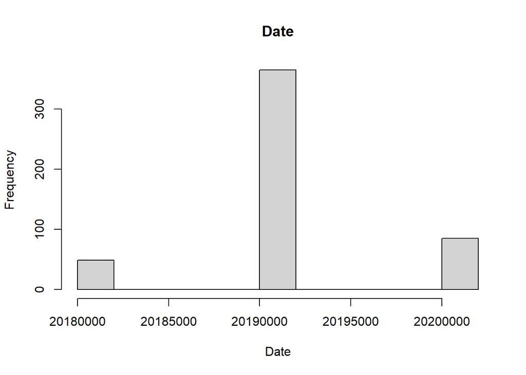

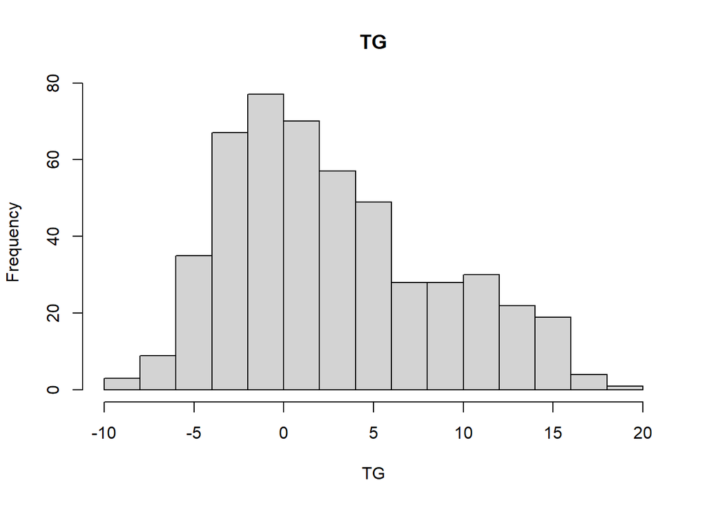

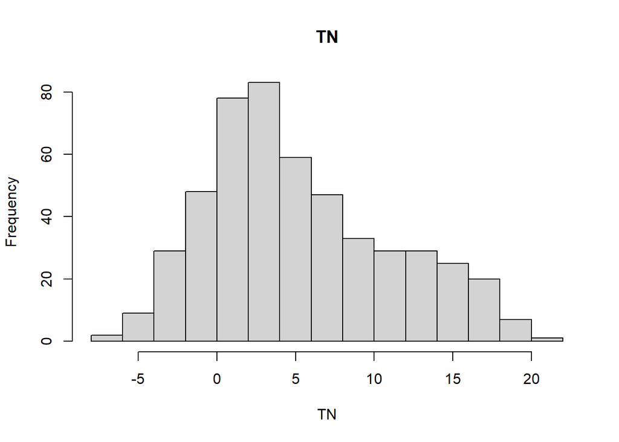

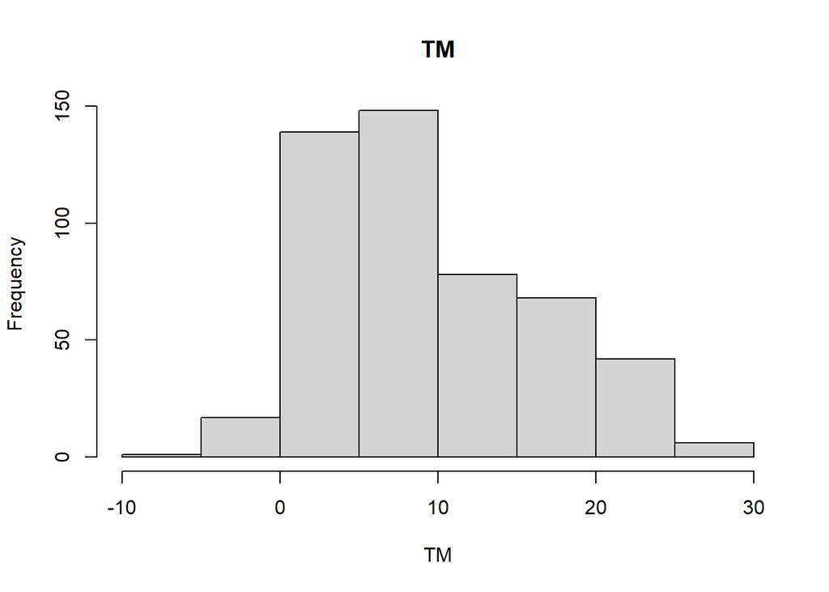

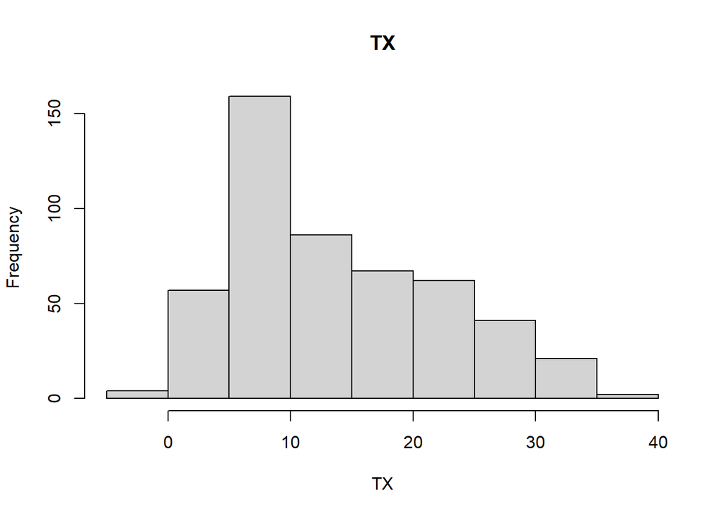

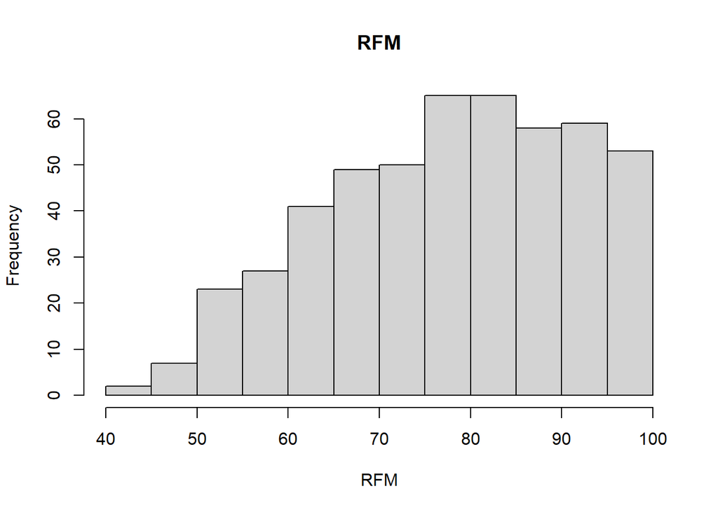

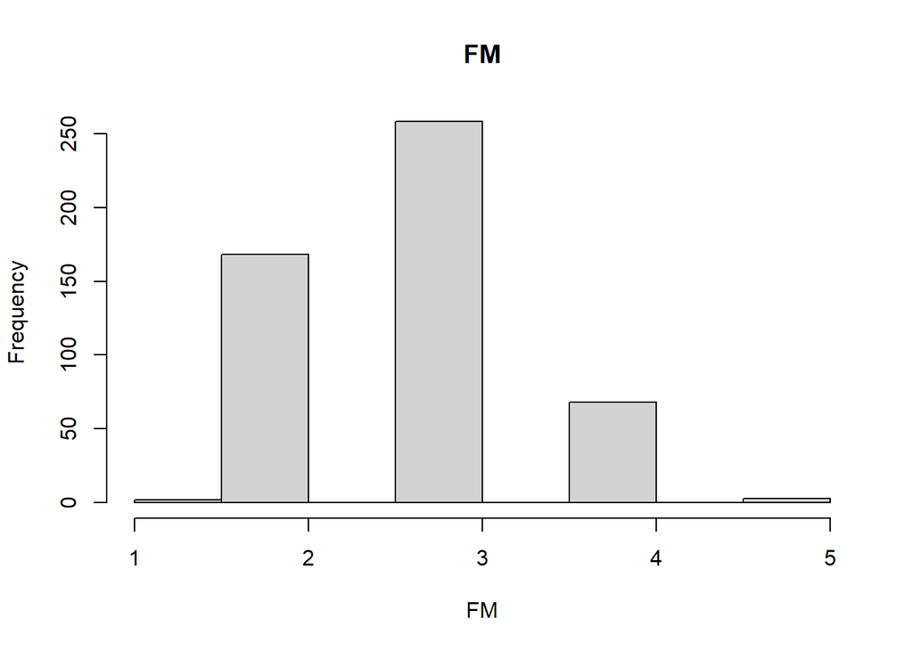

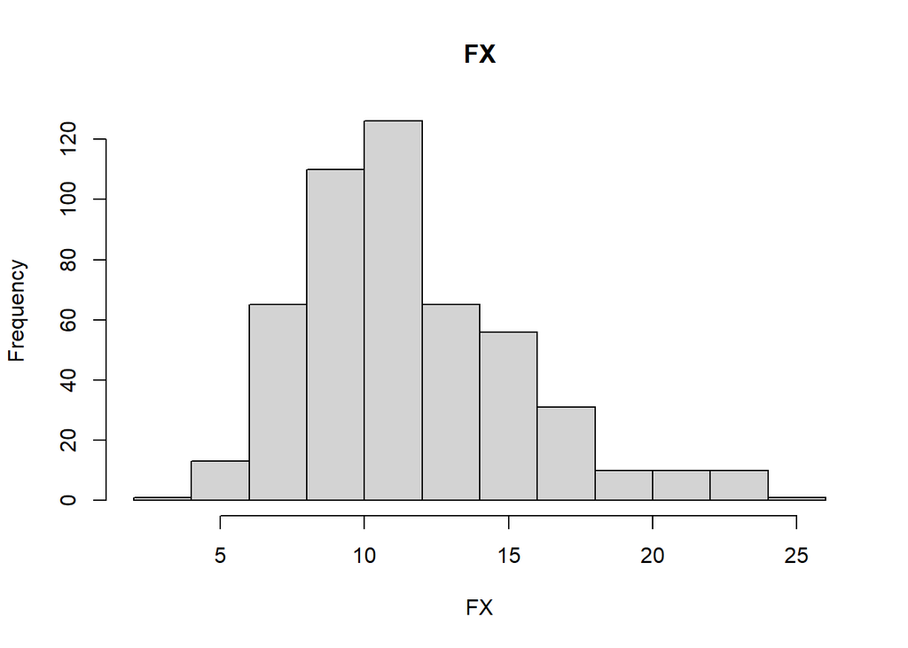

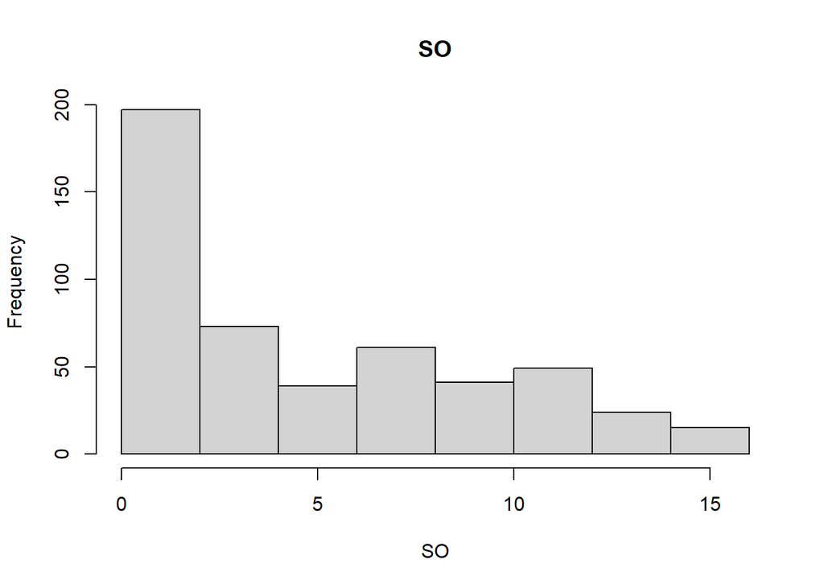

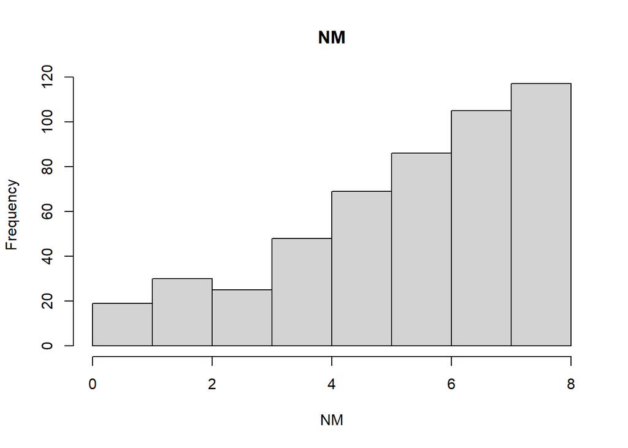

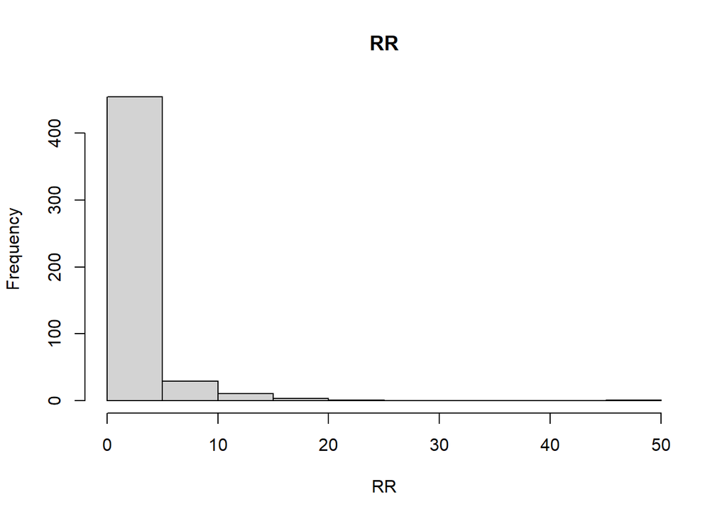

```r
for(col in colnames(df)) {
  hist(df[[col]], main = paste(col), xlab = col) }
```

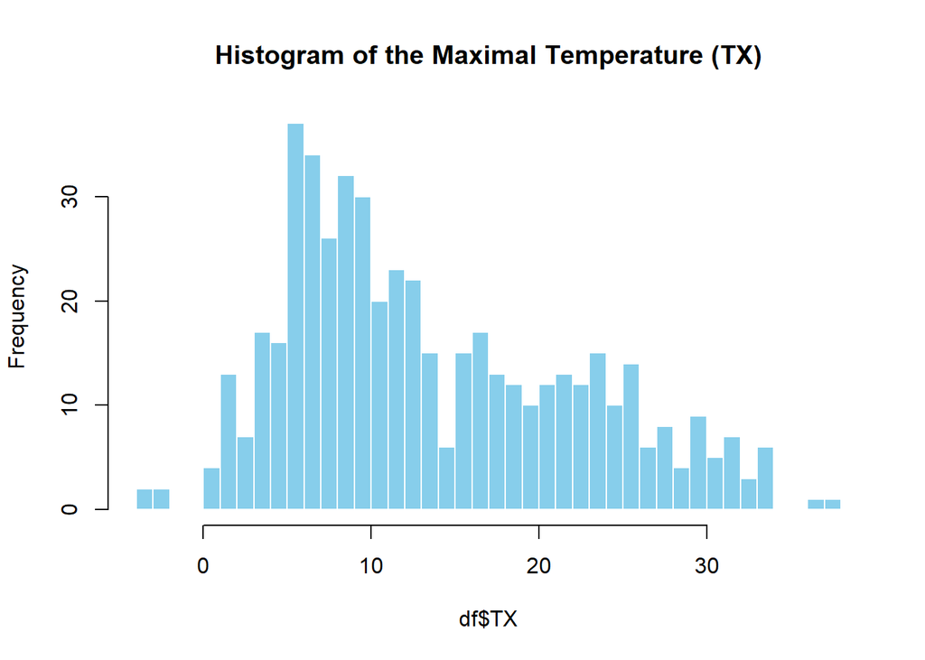

```r
# Again, drop columns that are not needed today
df <- df %>%
  select(-TG, -TM, -RFM, FM, -FX, -SO, -NM)

# Plotting the histogram
hist(df$TX,
     main = "Histogram of the Maximal Temperature (TX)",
     col = "skyblue",
     border = "white",
     breaks = 30)
```

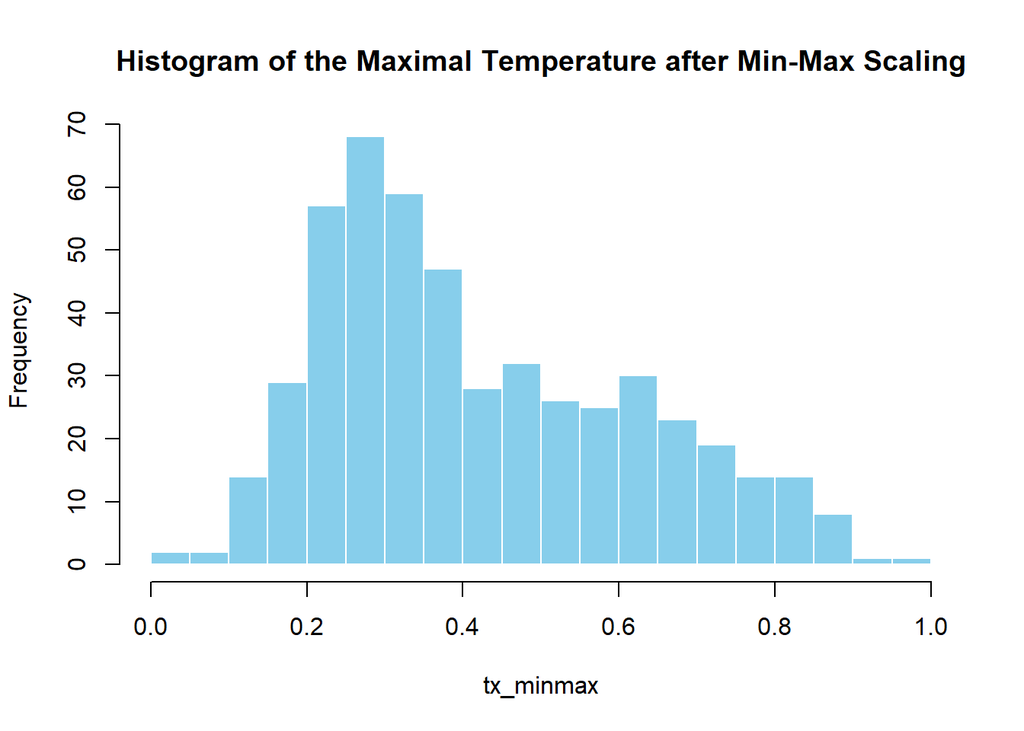

```r
#min-max-scaling
tx <- df$TX
tx_minmax <- (tx - min(tx) + 1) / (max(tx) - min(tx) + 2)

# Plotting the histogram
hist(tx_minmax,
     main = "Histogram of the Maximal Temperature after Min-Max Scaling",
     col = "skyblue",
     border = "white",
     breaks = 30)
```

As we can see, the data now lies in the open interval ]0,1[. However, this step did not change the distribution. To obtain a more symmetric distribution and, ultimately, a dataset defined over the entire real space, we next apply a log transformation.

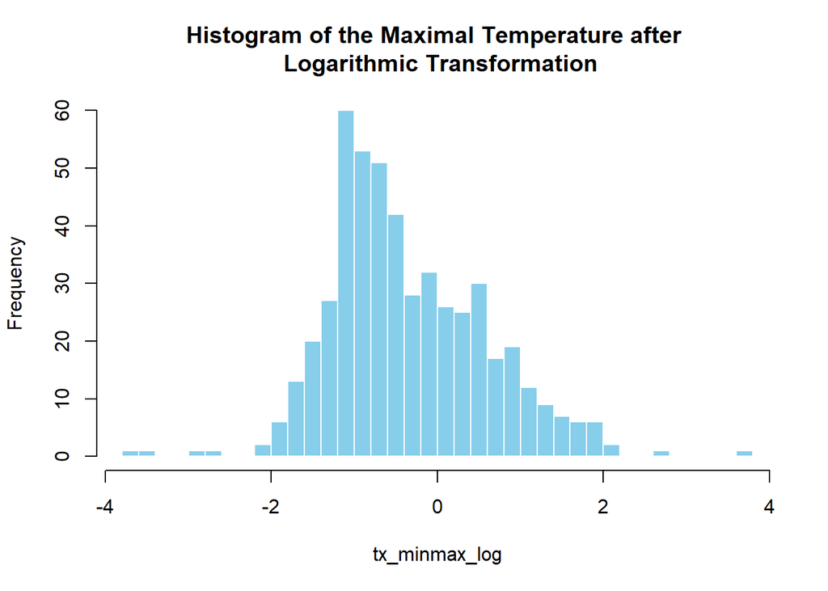

```r
#log transformation
tx_minmax_log <- log(tx_minmax / (1 - tx_minmax))

# Plotting the histogram
hist(tx_minmax_log,
     main = "Histogram of the Maximal Temperature after \n Logarithmic Transformation",
     col = "skyblue",
     border = "white",
     breaks = 30)
```

Let us do the same for Minimal Temperature:

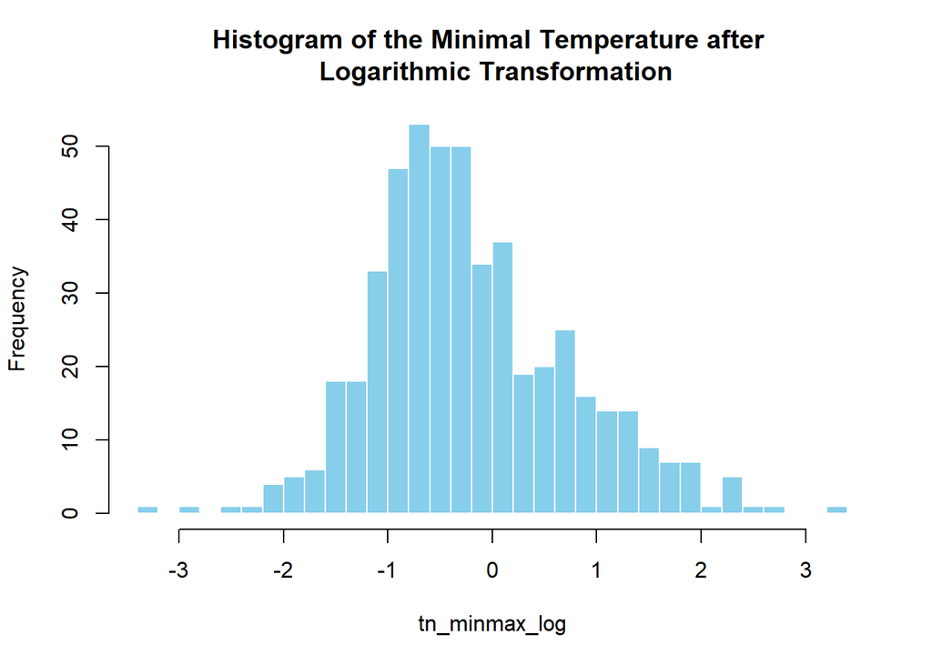

```r
tn <- df$TN
#1. min-max-scaling:
tn_minmax <- (tn - min(tn) + 1) / (max(tn) - min(tn) + 2)
#2. log-transformation:
tn_minmax_log <- log(tn_minmax / (1 - tn_minmax))

# Plotting the histogram
hist(tn_minmax_log,
     main = "Histogram of the Minimal Temperature after \n Logarithmic Transformation",
     col = "skyblue",
     border = "white",
     breaks = 30)
```

The transformed data now looks much more symmetric than the original dataset. We will add it to our dataframe and sort the dataset by date from 2018 to 2020.

```r
# add new columns
df$`TX transformed` <- tx_minmax_log
df$`TN transformed` <- tx_minmax_log

#sort by Date (2018...2020)
df <- df[order(df$Date), ]
```

### Date and Time Series in R

The core data object for holding data in R is the data.frame object. The data.frame object, however, is not designed to work efficiently with time series data. Fortunately, there are several R packages, such as ts, zoo, xts, lubridate, and forecast, among others, with functions for creating, manipulating and visualizing time date and time series objects.

What is the data type of the column where the dates are stored?

```r
class(df$Date)
```

```
## [1] "integer"
```

The data type is integer (int64), but we would like to transform these numbers into the data type Date:

```r
#as.Date does not work on integers, so we first convert the column to character, then to Date
df$Date <- as.character(df$Date)
df$Date <- as.Date(df$Date, format = "%Y%m%d")

head(df$Date)
```

```
## [1] "2018-11-13" "2018-11-14" "2018-11-15" "2018-11-16" "2018-11-17"
## [6] "2018-11-18"
```

```r
class(df$Date)
```

```
## [1] "Date"
```

Well down! The data type is now Date!

The package xts (eXtensible Time Series) is very useful when working with time series. Let’s convert our data frame to a xts object. This is only possible because we have already converted a column to the Date class.

```r
df_xts <- as.xts(df)
class(df_xts)
```

```
## [1] "xts" "zoo"
```

```r
head(df_xts)
```

```
##              TN   TX FM  RR TX transformed TN transformed
## 2018-11-13  6.8 12.3  2 8.9     -0.4481901     -0.4481901
## 2018-11-14  4.7 11.0  2 0.0     -0.5769757     -0.5769757
## 2018-11-15  4.2 10.4  3 0.0     -0.6379608     -0.6379608
## 2018-11-16  1.6  9.3  3 0.0     -0.7529189     -0.7529189
## 2018-11-17 -2.5  5.5  3 0.0     -1.1969482     -1.1969482
## 2018-11-18 -3.8  5.8  2 0.0     -1.1582846     -1.1582846
```

By doing this, the Date column is now the index, making it easy to extract specific dates.

```r
#We can look at the data of a certain time:
weather_newyear19 <- df_xts["2019-01-01"]
weather_newyear19
```

```
##             TN  TX FM  RR TX transformed TN transformed
## 2019-01-01 3.1 8.5  5 2.2     -0.8395758     -0.8395758
```

```r
#or we can have a look at the data of a certain time interval: How was the weather in June, July and August in 2019?
weather_summer19 <- df_xts["2019-06/2019-08"]
head(weather_summer19)
```

```
##              TN   TX FM  RR TX transformed TN transformed
## 2019-06-01 14.0 27.1  2 0.0       1.010810       1.010810
## 2019-06-02 14.6 31.3  2 0.0       1.590074       1.590074
## 2019-06-03 15.6 33.2  3 0.0       1.943261       1.943261
## 2019-06-04 17.2 30.6  2 0.0       1.478760       1.478760
## 2019-06-05 16.0 33.6  3 0.0       2.030776       2.030776
## 2019-06-06 14.5 31.7  3 5.4       1.657538       1.657538
```

```r
tail(weather_summer19)
```

```
##              TN   TX FM  RR TX transformed TN transformed
## 2019-08-26 16.8 31.7  2 1.6       1.657538       1.657538
## 2019-08-27 17.2 31.4  2 0.0       1.606656       1.606656
## 2019-08-28 17.7 33.4  2 0.0       1.986292       1.986292
## 2019-08-29 16.3 30.0  3 0.0       1.389197       1.389197
## 2019-08-30 19.5 29.9  2 0.0       1.374734       1.374734
## 2019-08-31 18.0 33.4  2 0.0       1.986292       1.986292
```

Another advantage is how easily the data can be plotted now:

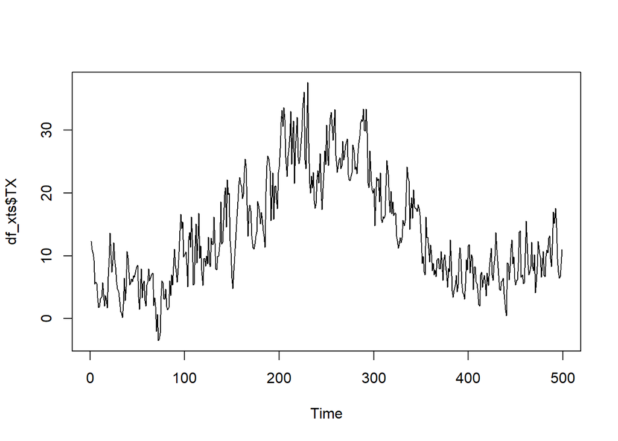

```r
plot.ts(df_xts$TX)
```

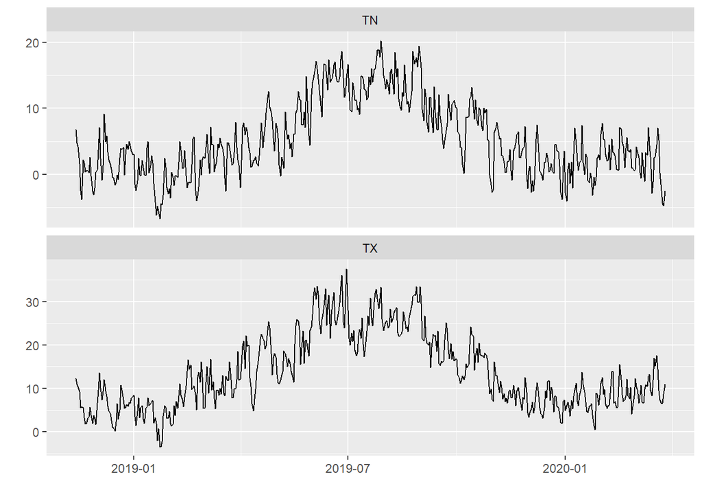

```r
# or with the autoplot() function
autoplot(df_xts[, c("TN", "TX")])
```

An xts object can also be indexed by any sequence. For example we may select every seventh day in a certain time period.

```r
# write sequence
dates <- seq(as.Date("2019-01-15"),
  as.Date("2019-04-12"),
  by = 7
)

df_xts[dates]
```

```
##              TN   TX FM  RR TX transformed TN transformed
## 2019-01-15  1.3  6.5  4 1.6     -1.0709608     -1.0709608
## 2019-01-22 -5.6  0.7  2 0.0     -1.9862925     -1.9862925
## 2019-01-29 -2.0  3.2  3 0.0     -1.5254915     -1.5254915
## 2019-02-05 -0.3  3.7  3 0.0     -1.4483527     -1.4483527
## 2019-02-12  1.0  5.8  3 0.1     -1.1582846     -1.1582846
## 2019-02-19  1.5  9.8  3 0.5     -0.7001158     -0.7001158
## 2019-02-26  2.2 11.4  2 0.0     -0.5368979     -0.5368979
## 2019-03-05  1.7  8.9  4 0.8     -0.7958923     -0.7958923
## 2019-03-12  1.8  9.5  3 0.7     -0.7316808     -0.7316808
## 2019-03-19 -0.6  8.3  3 0.0     -0.8617025     -0.8617025
## 2019-03-26  1.6  7.8  3 1.1     -0.9179154     -0.9179154
## 2019-04-02  2.1 15.7  3 0.0     -0.1254543     -0.1254543
## 2019-04-09  3.3 12.4  3 0.0     -0.4384458     -0.4384458
```

#### **Exercise**

Was the sun shining in summer 2019? Plot the Sonnenscheindauer ‘SO’ (or another variable) from the DWD data set for the time slice Mai, Juni, July and August 2019

### Summary Statistics:

Recall the basic functions for statistics in R:

- Quantiles: quantile(data, probs = 0.5)
- Median: median(data)
- Arithmetic Mean: mean(data)
- Geometric Mean: geometric.mean(data) from library “psych”
- Variance: var(data)
- Standard deviation: sd(data)

To get a quick overview on the statistical characteristics of time series we can also use the summary() function. The function returns basic statistics for the whole data set.

```r
# for the whole data:
summary(df_xts)
```

```
##      Index                  TN               TX              FM
##  Min.   :2018-11-13   Min.   :-6.800   Min.   :-3.50   Min.   :1.000
##  1st Qu.:2019-03-17   1st Qu.: 0.950   1st Qu.: 7.00   1st Qu.:2.000
##  Median :2019-07-20   Median : 4.100   Median :11.40   Median :3.000
##  Mean   :2019-07-20   Mean   : 5.308   Mean   :13.66   Mean   :2.804
##  3rd Qu.:2019-11-21   3rd Qu.: 9.400   3rd Qu.:20.15   3rd Qu.:3.000
##  Max.   :2020-03-25   Max.   :20.300   Max.   :37.60   Max.   :5.000
##        RR         TX transformed    TN transformed
##  Min.   : 0.000   Min.   :-3.7400   Min.   :-3.7400
##  1st Qu.: 0.000   1st Qu.:-1.0108   1st Qu.:-1.0108
##  Median : 0.000   Median :-0.5369   Median :-0.5369
##  Mean   : 1.424   Mean   :-0.3513   Mean   :-0.3513
##  3rd Qu.: 1.200   3rd Qu.: 0.2897   3rd Qu.: 0.2897
##  Max.   :48.000   Max.   : 3.7400   Max.   : 3.7400
```

```r
# or for just a time slice:
summary(df_xts["2019-06/2019-08"])
```

```
##      Index                  TN              TX              FM
##  Min.   :2019-06-01   Min.   : 8.70   Min.   :17.40   Min.   :2.0
##  1st Qu.:2019-06-23   1st Qu.:12.35   1st Qu.:23.52   1st Qu.:2.0
##  Median :2019-07-16   Median :14.50   Median :26.30   Median :2.0
##  Mean   :2019-07-16   Mean   :14.30   Mean   :26.77   Mean   :2.5
##  3rd Qu.:2019-08-08   3rd Qu.:16.38   3rd Qu.:30.07   3rd Qu.:3.0
##  Max.   :2019-08-31   Max.   :20.30   Max.   :37.60   Max.   :4.0
##        RR         TX transformed    TN transformed
##  Min.   : 0.000   Min.   :0.03249   Min.   :0.03249
##  1st Qu.: 0.000   1st Qu.:0.62009   1st Qu.:0.62009
##  Median : 0.000   Median :0.91792   Median :0.91792
##  Mean   : 1.720   Mean   :1.05096   Mean   :1.05096
##  3rd Qu.: 0.125   3rd Qu.:1.40024   3rd Qu.:1.40024
##  Max.   :48.000   Max.   :3.74005   Max.   :3.74005
```

#### **Exercise**

1. Plot the distribution of the precipitation (RR).
2. Discuss: Consider the histogram and the statistics of the precipiation (RR). Does the standard deviation given by the describe function make sense?

### What to do with missing values (NaNs)?

Missing values in data sets are a well-known problem as nearly everywhere, where data is measured and recorded, issues with missing values occur. Missing values can lead to problems, because often further data processing and analysis steps rely on complete data sets. Therefore missing values need to be replaced with reasonable values. In statistics this process is called **imputation**.

### Imputation of univariate time series

Techniques capable of doing imputation for univariate time series can be roughly divided into three categories ([Moritz et al. 2015](https://arxiv.org/abs/1510.03924)):

- **Univariate algorithms** These algorithms work with univariate inputs, but typically do not employ the time series character of the data set. Examples are: *mean*, *mode*, *median*, *random sample*.
- **Univariate time series algorithms** These algorithms are also able to work with univariate inputs, but make use of the time series characteristics. Examples of simple algorithms of this category are *last observation carried forward (locf)*, *next observation carried backward (nocb)*, *arithmetic smoothing* and *linear interpolation*. The more advanced algorithms are based on structural time series models and can handle seasonality.
- **Multivariate algorithms on lagged data** Usually, multivariate algorithms can not be applied on univariate data. But since time is an implicit variable for time series, it is possible to add time information as covariates in order to make it possible to apply multivariate imputation algorithms.

Let us test our possibilities to handle missing data and load the data set `Tagesmittel_Dahlem_MD.csv`

```r
# Read the data set, in this case missing values are ""
df_MD <- read.csv2("Tagesmittel_Dahlem_MD.csv", na.strings = c("", "NA"))

# Name the columns
colnames(df_MD) <- c('STAT', 'Date', 'QN', 'TG', 'TN', 'TM', 'TX', 'RFM', 'FM', 'FX', 'SO', 'NM', 'RR', 'PM')

# Drop columns we want to ignore:
df_MD <- df_MD %>%
  select(-STAT, -QN, -PM)

#Convert the Date column to data type date
df_MD$Date <- as.character(df_MD$Date)
df_MD$Date <- as.Date(df_MD$Date, format = "%Y%m%d")

#Convert other values to data type numeric
df_MD$TG <- as.numeric(df_MD$TG)
df_MD$TN <- as.numeric(df_MD$TN)
df_MD$TM <- as.numeric(df_MD$TM)
df_MD$TX <- as.numeric(df_MD$TX)
df_MD$RFM <- as.numeric(df_MD$RFM)
df_MD$FM <- as.numeric(df_MD$FM)
df_MD$FX <- as.numeric(df_MD$FX)
df_MD$SO <- as.numeric(df_MD$SO)
df_MD$NM <- as.numeric(df_MD$NM)
df_MD$RR <- as.numeric(df_MD$RR)

#Sort by ascending Date (2018...2020)
df_MD <- df_MD[order(df_MD$Date), ]
```

Count the numbers of NaN in each column

```r
na_count <- colSums(is.na(df_MD))
na_count
```

```
## Date   TG   TN   TM   TX  RFM   FM   FX   SO   NM   RR
##    0    4    8    8    3    5    1    4    2    1    3
```

```r
#calculate percentage
na_perc <- na_count/nrow(df_MD)
na_perc
```

```
##        Date          TG          TN          TM          TX         RFM
## 0.000000000 0.008130081 0.016260163 0.016260163 0.006097561 0.010162602
##          FM          FX          SO          NM          RR
## 0.002032520 0.008130081 0.004065041 0.002032520 0.006097561
```

Fill the NaN values with a specific value:

```r
df_MD$RR_fil <- df_MD$RR
df_MD$RR_fil[is.na(df_MD$RR_fil)] <- 0

head(df_MD$RR)
```

```
## [1] 8.9 0.0 0.0  NA 0.0 0.7
```

```r
head(df_MD$RR_fil)
```

```
## [1] 8.9 0.0 0.0 0.0 0.0 0.7
```

Instead of filling NaNs by a single value we can also fill by e.g. monthly or weekly means.

```r
#Add columns with year, month...
df_MD$Year <- year(df_MD$Date)
df_MD$Month <- month(df_MD$Date)

#Group the data by e.g. month, year, weekday etc.
#Then fill the NaNs with the corresponding e.g. median

df_fill <- df_MD %>%
  group_by(Month) %>%
  mutate(across(where(is.numeric),
                ~ ifelse(is.na(.), median(., na.rm = TRUE), .))) %>%
  ungroup()

head(df_MD)
```

```
##           Date   TG   TN  TM   TX  RFM FM   FX  SO  NM  RR RR_fil Year Month
## 492 2018-11-13  4.4  6.8 9.7 12.3 97.4  2 11.2 1.1 6.0 8.9    8.9 2018    11
## 491 2018-11-14  1.2  4.7 7.2 11.0 96.1  2  8.8 6.4 5.0 0.0    0.0 2018    11
## 490 2018-11-15  1.1   NA 6.3 10.4 93.0  3  8.5 0.5 4.6 0.0    0.0 2018    11
## 489 2018-11-16 -1.6  1.6 5.0  9.3 79.9  3 11.5 8.2 2.3  NA    0.0 2018    11
## 488 2018-11-18 -6.4 -3.8 1.6  5.8 87.8  2  9.8 1.6 5.0 0.0    0.0 2018    11
## 487 2018-11-19 -0.1  2.2 3.9  5.6 88.3  4 15.4 0.5 6.6 0.7    0.7 2018    11
```

```r
head(df_fill)
```

```
## # A tibble: 6 × 14
##   Date          TG    TN    TM    TX   RFM    FM    FX    SO    NM    RR RR_fil
##   <date>     <dbl> <dbl> <dbl> <dbl> <dbl> <dbl> <dbl> <dbl> <dbl> <dbl>  <dbl>
## 1 2018-11-13   4.4  6.8    9.7  12.3  97.4     2  11.2   1.1   6     8.9    8.9
## 2 2018-11-14   1.2  4.7    7.2  11    96.1     2   8.8   6.4   5     0      0
## 3 2018-11-15   1.1  2.35   6.3  10.4  93       3   8.5   0.5   4.6   0      0
## 4 2018-11-16  -1.6  1.6    5     9.3  79.9     3  11.5   8.2   2.3   0      0
## 5 2018-11-18  -6.4 -3.8    1.6   5.8  87.8     2   9.8   1.6   5     0      0
## 6 2018-11-19  -0.1  2.2    3.9   5.6  88.3     4  15.4   0.5   6.6   0.7    0.7
## # ℹ 2 more variables: Year <dbl>, Month <dbl>
```

Check if all NaN values are filled and calculate the sum of the NaN values again:

```r
na_count <- colSums(is.na(df_fill))
na_count
```

```
##   Date     TG     TN     TM     TX    RFM     FM     FX     SO     NM     RR
##      0      0      0      0      0      0      0      0      0      0      0
## RR_fil   Year  Month
##      0      0      0
```

#### **Exercise**

1. Load the data set Tagesmittel_Dahlem_MD.csv
2. Fill the missing values of the maximal temperature variable TX with the monthly mean
3. Calculate and plot the weekly mean or medians of maximal temperature variable TX

### Missing data (rows)

Next, we use the drop function to create some missing data rows of our data set:

```r
df_misrows <- df_fill
df_misrows <- df_fill[-c(4,8), ]

df_complete_nan <- df_misrows %>%
  complete(Date = seq(min(Date), max(Date), by = "day"))

head(df_complete_nan)
```

```
## # A tibble: 6 × 14
##   Date          TG    TN    TM    TX   RFM    FM    FX    SO    NM    RR RR_fil
##   <date>     <dbl> <dbl> <dbl> <dbl> <dbl> <dbl> <dbl> <dbl> <dbl> <dbl>  <dbl>
## 1 2018-11-13   4.4  6.8    9.7  12.3  97.4     2  11.2   1.1   6     8.9    8.9
## 2 2018-11-14   1.2  4.7    7.2  11    96.1     2   8.8   6.4   5     0      0
## 3 2018-11-15   1.1  2.35   6.3  10.4  93       3   8.5   0.5   4.6   0      0
## 4 2018-11-16  NA   NA     NA    NA    NA      NA  NA    NA    NA    NA     NA
## 5 2018-11-17  NA   NA     NA    NA    NA      NA  NA    NA    NA    NA     NA
## 6 2018-11-18  -6.4 -3.8    1.6   5.8  87.8     2   9.8   1.6   5     0      0
## # ℹ 2 more variables: Year <dbl>, Month <dbl>
```

And as our final step, we fill in those missing rows.

```r
#fill NaN values/rows with -999
df_complete <- replace(df_complete_nan, is.na(df_complete_nan), -999)
head(df_complete)
```

```
## # A tibble: 6 × 14
##   Date           TG      TN     TM     TX    RFM    FM     FX     SO     NM
##   <date>      <dbl>   <dbl>  <dbl>  <dbl>  <dbl> <dbl>  <dbl>  <dbl>  <dbl>
## 1 2018-11-13    4.4    6.8     9.7   12.3   97.4     2   11.2    1.1    6
## 2 2018-11-14    1.2    4.7     7.2   11     96.1     2    8.8    6.4    5
## 3 2018-11-15    1.1    2.35    6.3   10.4   93       3    8.5    0.5    4.6
## 4 2018-11-16 -999   -999    -999   -999   -999    -999 -999   -999   -999
## 5 2018-11-17 -999   -999    -999   -999   -999    -999 -999   -999   -999
## 6 2018-11-18   -6.4   -3.8     1.6    5.8   87.8     2    9.8    1.6    5
## # ℹ 4 more variables: RR <dbl>, RR_fil <dbl>, Year <dbl>, Month <dbl>
```

```r
#fill NaN values/rows with last valid value
df_complete <- na.locf(df_complete_nan) #Last Observation Carried Forward
head(df_complete)
```

```
## # A tibble: 6 × 14
##   Date          TG    TN    TM    TX   RFM    FM    FX    SO    NM    RR RR_fil
##   <date>     <dbl> <dbl> <dbl> <dbl> <dbl> <dbl> <dbl> <dbl> <dbl> <dbl>  <dbl>
## 1 2018-11-13   4.4  6.8    9.7  12.3  97.4     2  11.2   1.1   6     8.9    8.9
## 2 2018-11-14   1.2  4.7    7.2  11    96.1     2   8.8   6.4   5     0      0
## 3 2018-11-15   1.1  2.35   6.3  10.4  93       3   8.5   0.5   4.6   0      0
## 4 2018-11-16   1.1  2.35   6.3  10.4  93       3   8.5   0.5   4.6   0      0
## 5 2018-11-17   1.1  2.35   6.3  10.4  93       3   8.5   0.5   4.6   0      0
## 6 2018-11-18  -6.4 -3.8    1.6   5.8  87.8     2   9.8   1.6   5     0      0
## # ℹ 2 more variables: Year <dbl>, Month <dbl>
```

## Exercises Preprocessing:

> **Exercise 2**  
> 1. Load the data set Tagesmittel_Dahlem_MD.csv  
> 2. Fill the missing values of the maximal temperature TX variable with the monthly mean  
> 3. Calculate and plot the weekly mean of the maximal temperature variable

> **Exercise 3**  
> Compute the weekly and monthly means or medians of the maximal temperature TX of the DWD data set in the time range 1.1.2019 – 31.12.2019. Plot the results.

## STL Decomposition

Time series data is a collection of quantities that are recorded at regular intervals over time and ordered chronologically. The time interval at which the data is collected is generally referred to as the time series frequency. Some interesting questions are:

- Are there seasonal patterns? For example, in the time series of temperature? (this script)
- Does the data show trends that allow us to make assumptions about the future?
- How do we deal with missing data? (last script)

### Seasonal decompositon

Time series data can exhibit a huge variety of temporal patterns. In many cases it is useful to categorize these patterns, and further, split them up into distinct components. In general many time series can be decomposed into three parts:

- **Trend**: A trend exists when there is a long-term increase or decrease in the data.
- **Seasonal pattern**: A seasonal pattern exists when a series is influenced by seasonal factors. Seasonality is always of a fixed and known period.
- **Residual**: The remainder, after accounting for the trend and seasonality; also known as noise.

Referring to the three terms from above we can think of a time series $y_t$ as consisting of these three components: a seasonal component, a trend-cycle component (containing both trend and cycle), and a remainder component (containing anything else in the time series).

We can principally model such a time series in two ways: as an **additive model** and as a **multiplicative model**.

The additive model can be written as

$$y_t = T_t + S_t + R_t\text{,}$$
and the multiplicative model can be written as

$$y_t = T_t \times S_t \times
R_t\text{,}$$

where $y_t$ is the data at period $t$, $T_t$ is the trend-cycle component, $S_t$ is the seasonal component and $R_t$ is the remainder component at period $t$.

The additive model is most appropriate if the magnitude of the seasonal fluctuations or the variation around the trend-cycle does not vary with the level of the time series. When the variation in the seasonal pattern, or the variation around the trend-cycle, appears to be proportional to the level of the time series, then a multiplicative model is more appropriate.